# Assignment4

Shone George Kutty Renjan

2024-11-18

## 10/10

# Problems

```r
getwd()
```

```
## [1] "/Users/shonerenjan/Desktop/ASM/Assignments/Assignment4"
```

## 1. MS 7.118

```r
df<-read.csv("NZBIRDS.csv")
df
```

```
##         Species               Name Extinct Habitat Nest.Site Nest.Density Diet
## 1        Grebes       P. cristatus      No       A         G            L    F
## 2        Grebes      P. rufopectus      No       A         G            L    F
## 3       Petrels           P. gavia     Yes       A        GC            H    F
## 4       Petrels         P. huttoni  Absent       A        GC            H    F
## 5       Petrels        P. spelaeus  Absent       A        GC            H    F
## 6       Petrels       P. assimilis     Yes       A        GC            H    F
## 7       Petrels       P. urinatrix     Yes       A        GC            H    F
## 8       Petrels       P. georgicus      No       A        GC            H    F
## 9       Petrels          P. turtur     Yes       A        GC            H    F
## 10      Petrels        P. pycrofti     Yes       A        GC            H    F
## 11      Petrels          P. cookii      No       A        GC            H    F
## 12      Petrels          G. nereis     Yes       A        GC            H    F
## 13      Petrels          P. marina     Yes       A        GC            H    F
## 14      Petrels     P. inexpectata      No       A        GC            H    F
```

[output cut: 251 more lines]

### a.

Use a random number generator to select a random sample of 35 species from the NZBIRDS file.

```r
set.seed(5)
sam <- runif(35,1,116)
```

### b.

Calculate the mean and standard deviation for the 35 sampled values of body mass. Then, use this informa- tion to construct a 95% confidence interval for the mean body mass of all 116 bird species.

```r
BodyMass <- df$Body.Mass[sam]
mean(BodyMass)
```

```
## [1] 656.8
```

```r
sd(BodyMass)
```

```
## [1] 950.0844
```

### c.

Give a practical interpretation of the interval, part b.

```r
sam_int = t.test(BodyMass, conf.level = 0.95)$conf.int
sam_int
```

```
## [1] 330.4346 983.1654
## attr(,"conf.level")
## [1] 0.95
```

```r
MATH4753SHON2024::myci(BodyMass,0.05)
```

```
## Lower Bound: 330.4346 Upper Bound: 983.1654
```

```
## [1] 330.4346 983.1654
```

At 95% confidence level of mean value of body mass for the birds is between 330.4346 and 983.1654.

### d.

Check to see if the true mean, m (shown on the MINITAB printout), is included in the confidence interval, part b. Explain why the interval is very likely to contain m.

Since the real mean of the birds’ body mass value will be present in 95% of the intervals generated, it is highly likely to include $\mu$.

### e.

Repeat parts b–d for the 35 sampled values of egg length.

```r
set.seed(5)
sam1 <- runif(35,1,116)
```

```r
EggLength <- df$Egg.Length[sam1]
mean(EggLength)
```

```
## [1] 44.04286
```

```r
sd(EggLength)
```

```
## [1] 17.05716
```

```r
MATH4753SHON2024::myci(EggLength,0.05)
```

```
## Lower Bound: 38.18352 Upper Bound: 49.9022
```

```
## [1] 38.18352 49.90220
```

At 95% confidence level of mean value of egg length for the birds is between 38.18352 and 49.9022

### f.

Ecologists also want to compare the proportions of flightless birds for two New Zealand bird populations—those that are extinct and those that are not extinct. Use the sample information in the table below to form a 95% confidence interval for the difference between the proportion of flightless birds for extinct and nonextinct species.
$$(\hat{p}_{ex} - \hat{p}_{non}) \pm
z_{\frac{\alpha}{2}}\sqrt{\frac{p_1q_1}{n_1} +
\frac{p_2q_2}{n_2}}$$

```r
p1=21/116
q1=1-p1
n1=21
p2=7/116
q2=1-p2
n2=7
alpha=0.05
z=qnorm(1-(alpha)/2, 0, 1)
Lower=p1-p2-z*sqrt((p1*q1)/n1 +(p2*q2)/n2)
Upper=p1-p2+z*sqrt((p1*q1)/n1 +(p2*q2)/n2)

cat("Lower Bound =", Lower, "Upper Boun =", Upper, "\n")
```

```
## Lower Bound = -0.1206369 Upper Boun = 0.3620163
```

### g.

The ecologists are investigating the theory that the pro- portion of flightless birds will be greater for extinct species than for nonextinct species. Does the confi- dence interval, part f, support this theory? Explain

Indeed, it lends credence to this notion, but it may also contradict it. This is so because both positive and negative values are included in the confidence interval.

## 2. MS 7.120

### a.

Estimate the difference between the mean shear strengths of epoxy-repaired truss joints for the two species of wood with a 90% confidence interval.
$$(\bar{y_1} -
\bar{y_2}) \pm z_{\alpha / 2}\sqrt{\frac{s_{1}^{2}}{n_1} +
\frac{s_{2}^{2}}{n_2}}$$

```r
ybar1= 1312
ybar2= 1352
sigmasquared1=(422)^2
sigmasquared2 = (271)^2
n1=100
n2=47

alpha=0.1
z=qnorm(1-(alpha)/2, 0, 1)
Lower=ybar1-ybar2- z*sqrt(sigmasquared1/n1 + sigmasquared2/n2)
Upper=ybar1-ybar2+z*sqrt(sigmasquared1/n1 + sigmasquared2/n2)
cat("The 90% confidence interval is [", Lower, ",", Upper, "]")
```

```
## The 90% confidence interval is [ -135.1092 , 55.10916 ]
```

### b.

Construct a 90% confidence interval for the ratio of the shear stress variances of epoxy-repaired truss joints for the two species of wood. Based on this interval, is there evidence to indicate that the two shear stress variances differ? Explain.

```r
var1=n1-1
var2=n2-2
lowerfq = sigmasquared1 / (sigmasquared2 * qf(1 - alpha/2, df1 = var1, df2 = var2))
upperfq = sigmasquared1 / sigmasquared2 * qf(1 - alpha/2, df1 = var2, df2 = var1)

cat("Lower Bound =",lowerfq , "Upper Bound =", upperfq, "\n")
```

```
## Lower Bound = 1.560003 Upper Bound = 3.626675
```

Given these findings, it is reasonable to conclude that the variances of the two shear stresses differ as the 90% CI does not include 1, indicating that $\sigma_{1}^{2}$ is larger than $\sigma_{2}^{2}$.

## 3. MS 7.128

### a.

Show that y2/s2 has a chi-square distribution with 1 degree of freedom. (Hint: The result follows directly from Theorem 6.11.
$$Z = \frac{Y - \mu}{\sigma};$$

When $\mu=0$
$$Z =\frac{Y }{\sigma}$$
Z^2 is a chi-sq distrubtion with a degree of freedom of 1
$$Z^2 =\frac{Y^2}{\sigma^2}$$
Theorum 6.11 states that:
$$\chi^2=\frac{(n-1)S^2}{\sigma^2}$$

### b.

Derive a 95% confidence interval for s2 using y2/s2 as a pivotal statistic.
$$P\left(\chi^2_{1 - \frac{\alpha}{2}} \leq \frac{Y^2}{\sigma^2} \leq
\chi^2_{\frac{\alpha}{2}}\right) = 1 - \alpha =
P\left(\frac{Y^2}{\chi^2_{\frac{\alpha}{2}}} \leq \sigma^2 \leq
\frac{Y^2}{\chi^2_{1 - \frac{\alpha}{2}}}\right)$$

## 4. MS 8.24

```r
df <- read.csv("ROUGHPIPE.csv")
Rough <-df$ROUGH
```

### a.

Give the null and alternative hypotheses for testing whether the mean surface roughness of coated interior pipe, $\mu$, differs from 2 micrometers.
$$Null: \mu=2\\ Alternative: \mu\neq 2$$

### b.

The results of the test, part a, are shown in the MINITAB printout at the bottom of the page. Locate the test statistic and p-value on the printout.
$$T_{stat}=-1.02\\
P_{value}=0.322$$

### c.

Give the rejection region for the hypothesis test, using a = .05 .

```r
df=length(Rough)-1
alpha=0.05
lower=qt(alpha/2,df)
upper=qt(1-alpha/2,df)

cat("The rejection regionis below:",lower , "and above:", upper, "\n")
```

```
## The rejection regionis below: -2.093024 and above: 2.093024
```

### d.

State the appropriate conclusion for the hypothesis test.

Conclution: Accept the Null hypothesis.

## 5. MS 8.28

```r
df <- read.csv("WISCLAKES.csv")
doc <- df$DOC
```

### a.

Use a hypothesis test (at a = .10 ) to make an inference about whether the sample is representative of all Wis- consin lakes for the characteristic, dissolved organic compound.

```r
t.test(doc, mu = 15, conf.level = 0.9)
```

```
##
##  One Sample t-test
##
## data:  doc
## t = -0.18668, df = 24, p-value = 0.8535
## alternative hypothesis: true mean is not equal to 15
## 90 percent confidence interval:
##  10.08013 18.95187
## sample estimates:
## mean of x
##    14.516
```

The sample is representative of all Wisconsin lakes for dissolved organic compound, as we fail to reject the null hypothesis. Given that the p-value (0.8535) is greater than the significance level (α = 0.10), we fail to reject the null hypothesis, suggesting the sample is representative of all Wisconsin lakes for dissolved organic compound.

### b.

What is the likelihood that the test, part a, will detect a mean that differs from 15 grams/m3 if, in fact, ma = 14 grams/m3?

```r
mu0=15
mua=14
n=25
sigma= sd(doc)
cp = (mu0-mua)/(sigma/(sqrt(n)))
cp
```

```
## [1] 0.3856927
```

## 6. MS 8.44

```r
df <- read.csv("ORCHARD.csv")
fog = df$RATIO[df$CONDITION == "FOG"]
fog = fog[!is.na(fog)]
clear = df$RATIO[df$CONDITION == "CLEAR" | df$CONDITION == "CLOUD"]
s1 = var(fog)
n1 = length(fog)
mu1 = mean(fog)
s2 = var(clear)
n2 = length(clear)
mu2 = mean(clear)
```

```r
sp =((n1 - 1) * s1 + (n2 - 1) * s2) / (n1 + n2 - 2)
sp
```

```
## [1] 0.02028222
```

```r
t <- (mu2 - mu1) / sqrt(sp * (1/n1 + 1/n2))
t
```

```
## [1] 2.04675
```

```r
qt(1-0.05/2, df = (n1+n2-2))
```

```
## [1] 2.228139
```

It is conceivable that the means of these ratios are the same under both scenarios because our T falls between -2.230 and 2.230.

## 7. MS 8.84

### a.

Conduct a test (at a = .05 ) for equality of heat rate variances for traditional and aeroderivative augmented df df. Use the result to make a statement about the validity of the inference derived in Exercise 8.33 a.

```r
df=read.csv("GASTURBINE.csv")
library(dplyr)
```

```r
df %>% filter(ENGINE == "Traditional" | ENGINE == "Aeroderiv") %>% var.test(HEATRATE ~ ENGINE, data =.)
```

```
##
##  F test to compare two variances
##
## data:  HEATRATE by ENGINE
## F = 4.297, num df = 6, denom df = 38, p-value = 0.004234
## alternative hypothesis: true ratio of variances is not equal to 1
## 95 percent confidence interval:
##   1.555004 21.574593
## sample estimates:
## ratio of variances
##           4.296996
```

The F-test result (F = 4.297, p-value = 0.004234) provides evidence that the variances of heat rates for Traditional and Aeroderivative df are significantly different, invalidating the equal variance assumption for Exercise 8.33.

### b.

Conduct a test (at a = .05 ) for equality of heat rate variances for advanced and aeroderivative augmented gas df. Use the result to make a statement about the validity of the inference derived in Exercise 8.39 b.

```r
HEATRATE = df$HEATRATE[df$ENGINE == "Advanced"]
ENGINE = df$HEATRATE[df$ENGINE == "Aeroderiv"]
var.test(HEATRATE, ENGINE, ratio = 1)
```

```
##
##  F test to compare two variances
##
## data:  HEATRATE and ENGINE
## F = 0.057974, num df = 20, denom df = 6, p-value = 1.192e-06
## alternative hypothesis: true ratio of variances is not equal to 1
## 95 percent confidence interval:
##  0.0112170 0.1813622
## sample estimates:
## ratio of variances
##         0.05797393
```

The F-test result (F = 0.057974, p-value = 1.192e-06) shows that the variances of heat rates for Advanced and Aeroderivative turbines are significantly different, invalidating the equal variance assumption in Exercise 8.39.

## 8. MS 8.99

```r
df <- read.csv("GOBIANTS.csv")
df
```

```
##    Site      Region Rain Temp PlantCov AntSpecies Diversity
## 1     1  Dry Steppe  196  5.7       40          3      0.89
## 2     2  Dry Steppe  196  5.7       52          3      0.83
## 3     3  Dry Steppe  179  7.0       40         52      1.31
## 4     4  Dry Steppe  197  8.0       43          7      1.48
## 5     5  Dry Steppe  149  8.5       27          5      0.97
## 6     6 Gobi Desert  112 10.7       30         49      0.46
## 7     7 Gobi Desert  125 11.4       16          5      1.23
## 8     8 Gobi Desert   99 10.9       30          4        NA
## 9     9 Gobi Desert  125 11.4       56          4      0.76
## 10   10 Gobi Desert   84 11.4       22          5      1.26
## 11   11 Gobi Desert  115 11.4       14          4      0.69
```

### a.

Set up H0 and Ha for determining whether the variances are the same.

If the ratio of var1/var2 equals 1 H1, then the variances are same. If the ratio of var1/var2 is not 1, the variances are not the same.

### b.

Use the data in the GOBIANTS file to find the test sta-tistic for the test.

```r
AntSpecies = df$AntSpecies[df$Region == "Dry Steppe"]
Region= df$AntSpecies[df$Region == "Gobi Desert"]
var.test(AntSpecies, Region, ratio = 1)
```

```
##
##  F test to compare two variances
##
## data:  AntSpecies and Region
## F = 1.3684, num df = 4, denom df = 5, p-value = 0.7264
## alternative hypothesis: true ratio of variances is not equal to 1
## 95 percent confidence interval:
##   0.1852264 12.8146380
## sample estimates:
## ratio of variances
##           1.368432
```

### c.

Give the rejection region for the test if a=0.05 .

```r
qf(0.05 / 2, 4, 5)
```

```
## [1] 0.1067866
```

```r
qf(1 - (0.05 / 2), 4, 5)
```

```
## [1] 7.387886
```

### d.

Find the approximate p-value of the test.

P-value :0.7264

### e.

Make the appropriate conclusion in the words of the problem.

The F-test result (F = 1.3684, p-value = 0.7264) indicates that there is no significant evidence to suggest that the variances of AntSpecies and Region are different, so we conclude that the variances are equal.

### f.

What conditions are required for the test results to be valid?

For the F-test results to be valid, the two datasets must be independent, approximately normally distributed, and measured on an interval or ratio scale.

## 9. MS 8.104

```r
df<-read.csv("THRUPUT.csv")
human <- df$HUMAN
auto <- df$AUTO

t.test(human, auto)
```

```
##
##  Welch Two Sample t-test
##
## data:  human and auto
## t = -1.441, df = 13.897, p-value = 0.1717
## alternative hypothesis: true difference in means is not equal to 0
## 95 percent confidence interval:
##  -81.06293  15.93793
## sample estimates:
## mean of x mean of y
##  210.8875  243.4500
```

## 10. 8.104

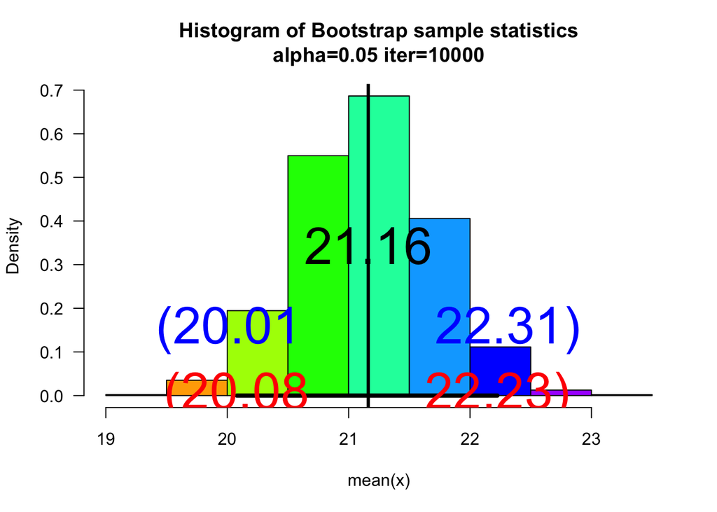

```
## $ci
##     2.5%    97.5%
## 20.07910 22.22545
##
## $fun
## [1] "mean"
##
## $x
##  [1] 23.195 20.399 19.898 19.865 30.014 18.821 21.232 18.313 23.574 21.047
## [11] 21.535 21.336 17.695 18.497 14.274 14.664 22.593 18.963 25.515 25.019
## [21] 22.053 22.871 23.006 23.829 19.038 21.735 21.461 21.659 21.703 21.049
##
## $t
## [1] 2.04675
```

```r
set.seed(35); sam <- round(rnorm(30,mean=20, sd=3),3)

myboot<-function(iter=10000,x,fun="mean",alpha=0.05,...){  #Notice where the ... is repeated in the code
n=length(x)   #sample size


df=n-1
s=sd(x)
ybar=mean(x)
t_quant=qt(1-alpha/2,df)
L=ybar-(t_quant*s)/(sqrt(n))
U=ybar+(t_quant*s)/(sqrt(n))

y=sample(x,n*iter,replace=TRUE)
rs.mat=matrix(y,nr=n,nc=iter,byrow=TRUE)
xstat=apply(rs.mat,2,fun) # xstat is a vector and will have iter values in it
ci=quantile(xstat,c(alpha/2,1-alpha/2))# Nice way to form a confidence interval
# A histogram follows
# The object para will contain the parameters used to make the histogram
para=hist(xstat,breaks=9,freq=FALSE,las=1,
main=paste("Histogram of Bootstrap sample statistics","\n","alpha=",alpha," iter=",iter,sep=""),
...)
para

#mat will be a matrix that contains the data, this is done so that I can use apply()
mat=matrix(x,nr=length(x),nc=1,byrow=TRUE)

#pte is the point estimate
#This uses whatever fun is
pte=apply(mat,2,fun)
abline(v=pte,lwd=3,col="Black")# Vertical line
segments(ci[1],0,ci[2],0,lwd=4)      #Make the segment for the ci
text(ci[1],0,paste("(",round(ci[1],2),sep=""),col="Red",cex=3)
text(ci[2],0,paste(round(ci[2],2),")",sep=""),col="Red",cex=3)
text(L,0.15,paste("(",round(L,2),sep=""),col="Blue",cex=3)
text(U,0.15,paste(round(U,2),")",sep=""),col="Blue",cex=3)

# plot the point estimate 1/2 way up the density
text(pte,max(para$density)/2,round(pte,2),cex=3)

return(list(ci=ci,fun=fun,x=x, t=t))# Some output to use if necessary
}
myboot(10000,x=sam,fun="mean",alpha=0.05,xlab="mean(x)",col=rainbow(9))
```